# LatexLibrary_Example

## Using the LatexLibrary

This library creates some report structure and basic tex files for you to efficiently write a latex report.

### 0. Create some Sample Data

Using a linear regression example from [sklearn](https://scikit-learn.org/stable/auto_examples/linear_model/plot_ols.html#sphx-glr-auto-examples-linear-model-plot-ols-py).

```python
import os
os.chdir('../src') # this file is in the notebooks folder.
```

```python
from lib.databaseIO import pgIO
import jsonref
projConfig = jsonref.load(open('../config/modules/module1.json'))

import pandas as pd
import numpy as np
import matplotlib.pyplot as plt
from sklearn import datasets, linear_model
from sklearn.model_selection import train_test_split
from sklearn.metrics import mean_squared_error, r2_score
import pickle
```

```python
# Load the diabetes dataset
diabetes = datasets.load_diabetes()
diabetes_df = pd.DataFrame(diabetes.data, columns=diabetes.feature_names)

pd.set_option('display.float_format', lambda x: '%.3f' % x)
descript = pd.DataFrame(diabetes.data, columns=diabetes.feature_names).describe()
```

```python
descript
```

|  | age | sex | bmi | bp | s1 | s2 | s3 | s4 | s5 | s6 |
| --- | --- | --- | --- | --- | --- | --- | --- | --- | --- | --- |
| count | 442.000 | 442.000 | 442.000 | 442.000 | 442.000 | 442.000 | 442.000 | 442.000 | 442.000 | 442.000 |
| mean | -0.000 | 0.000 | -0.000 | 0.000 | -0.000 | 0.000 | -0.000 | 0.000 | -0.000 | -0.000 |
| std | 0.048 | 0.048 | 0.048 | 0.048 | 0.048 | 0.048 | 0.048 | 0.048 | 0.048 | 0.048 |
| min | -0.107 | -0.045 | -0.090 | -0.112 | -0.127 | -0.116 | -0.102 | -0.076 | -0.126 | -0.138 |
| 25% | -0.037 | -0.045 | -0.034 | -0.037 | -0.034 | -0.030 | -0.035 | -0.039 | -0.033 | -0.033 |
| 50% | 0.005 | -0.045 | -0.007 | -0.006 | -0.004 | -0.004 | -0.007 | -0.003 | -0.002 | -0.001 |
| 75% | 0.038 | 0.051 | 0.031 | 0.036 | 0.028 | 0.030 | 0.029 | 0.034 | 0.032 | 0.028 |
| max | 0.111 | 0.051 | 0.171 | 0.132 | 0.154 | 0.199 | 0.181 | 0.185 | 0.134 | 0.136 |

```
Coefficients:
 [938.23786125]
Mean squared error: 2548.07
Variance score: 0.47
```

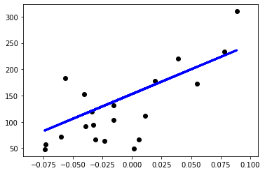

```python
diabetes_X = diabetes.data[:, np.newaxis, 2] # using only 1 feature

diabetes_X_train = diabetes_X[:-20]
diabetes_X_test = diabetes_X[-20:]
diabetes_y_train = diabetes.target[:-20]
diabetes_y_test = diabetes.target[-20:]

regr = linear_model.LinearRegression()
regr.fit(diabetes_X_train, diabetes_y_train)
diabetes_y_pred = regr.predict(diabetes_X_test)

# The coefficients
print('Coefficients: \n', regr.coef_)
# The mean squared error
print("Mean squared error: %.2f"
      % mean_squared_error(diabetes_y_test, diabetes_y_pred))
# Explained variance score: 1 is perfect prediction
print('Variance score: %.2f' % r2_score(diabetes_y_test, diabetes_y_pred))

# Plot outputs
plt.scatter(diabetes_X_test, diabetes_y_test,  color='black')
plt.plot(diabetes_X_test, diabetes_y_pred, color='blue', linewidth=3)

plt.savefig('../results/fig1.png')
plt.show()
```

```python
results = pd.DataFrame([('Coefficient(s)', regr.coef_),
                      ('Mean Squared Error', mean_squared_error(diabetes_y_test, diabetes_y_pred)),
                      ('Variance Score', r2_score(diabetes_y_test, diabetes_y_pred))
                     ], columns=['Results','Values'])
results.Results = results.Results.astype('str')
results.Values  = results.Values.astype('int')

results
```

|  | Results | Values |
| --- | --- | --- |
| 0 | Coefficient(s) | 938 |
| 1 | Mean Squared Error | 2548 |
| 2 | Variance Score | 0 |

```python
# separate dataframes
df1 = descript.s1
df2 = descript.s3
df3 = descript.s5
```

### 1. Initialize a Report Document

Create a report, give it a name, a title.  
Initialize to create the relevant directories.

```python
from lib.LaTeXreport import reportWriter as rw
```

```python
rep = rw.Report('Example1')
rep.title = "Report Example"
rep.author = "ME!"
rep.date = '25/09/2019'
rep.initialize(rep.fpath)
```

```
Created ../report/Example1
Created ../report/Example1/sections
Created ../report/Example1/tables
Created ../report/Example1/figures
Created ../report/Example1/mappingTables
Created ../report/Example1/output
>> Example1 report structure has been initialized.
```

## 2. Add Report Content

- Use `saveFigure` to add Figures from a specified existing file path to the newly created figures directory.
- Use `saveTable` to convert a pandas dataframe into a TEX file in the newly created tables directory.

Optional:

- `caption` for both tables and figures to be appended at the bottom
- `option` for figures to scale, adjust width/height.
- `override` for whether you want to re-generate the .png/.tex files.

```
Copying Figure1.png to ../report/Example1/figures.
```

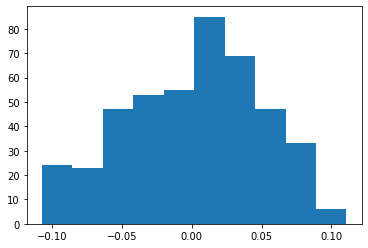

```python
### Add figures ###
# 1. by copying from other directory
rep.saveFigure('Figure1',
               '../results/fig1.png',
               caption='This is a plot of the linear reg output.',
               option='scale=0.6', override=True)

# 2. by saving or moving directly to figures folder
plt.hist(diabetes_df.age)
plt.savefig(rep.fpath+'/figures/Figure2.png')

# optional to add caption/option with saveFigure()
rep.saveFigure('Figure2',
               caption='This image was saved directly to the current folder.',
               option=r'width=0.5\textwidth')
```

```python
### Add tables ###
# 1. Add directly from pandas dataframe
rep.saveTable('Table1',
              descript,
              caption='Descriptive table of diabetes data.',
              override=False)

rep.saveTable('Table2',
              results,
              caption='Results of the Logisitic Regression',
              override=True)

# Option to add multiple dataframes to be merged together
rep.saveTable('Table3',
              [df1,df2,df3],
              caption='Merged dataframes example.',
              override=True)

# 2. Add tex files directly to tables folder
```

```
Written Table1.tex to ../report/Example1/tables/Table1.tex
Written Table2.tex to ../report/Example1/tables/Table2.tex
Written Table3.tex to ../report/Example1/tables/Table3.tex
```

## 3. Add report Sections

For each section you add and name, a `.tex` file will be created in the newly created sections directory. You can optionally specify the `level` of the section, to create subsections or even subsubsections.

```python
# Add sections
rep.addSection('Introduction')
rep.addSection('Logistic Regression')
rep.addSection('Data', level=2)
rep.addSection('Results')
rep.addSection('Conclusion')
```

```
Created section Introduction at ../report/Example1/sections/Introduction.tex
Created section Logistic Regression at ../report/Example1/sections/Logistic_Regression.tex
Created section Data at ../report/Example1/sections/Data.tex
Created section Results at ../report/Example1/sections/Results.tex
Created section Conclusion at ../report/Example1/sections/Conclusion.tex
```

## 4. Generate the Report

Specify whether you want to create a tex document only, otherwise a PDF document will also be made.

Figures and Tables will be appended to the bottom of the report, you have to move them to the correct sections/places yourself.

```python
# rep.makeReport(tex_only=True) # tex only
rep.makeReport() # pdf and tex
```

[output not shown]

[output cut: 180 more lines]

[output not shown]

[output not shown]

## 5. Write the Report

Now you can edit the report to your heart's content!

- Edit tex files under **Sections** by adding text directly
- **Figures/tables**
  - Configure the figures/tables that are already created, move them to the different sections
  - Add more by copying and pasting directly to the folders. Note that you will need to enter their caption/other configurations by yourself. Tables should already be in TEX format. Use `pd.to_latex()` to assist with this.
- **Appendix**
  - If you have mapping tables, you can add them to the mappingTables folder.
- Run `makeReport()` whenever you're done.

```python
os.chdir('~/reportWriterDemo/src')
rep.makeReport()
```